# TBI Study Results (pt. 3)

Eric Czech

23 February, 2016, 12:07

## Contents

- **Section 1**: Data Overview and Assumptions
- **Section 2**: Findings for PbtO2 + Outcome (where “outcome” means gos of 1,2,3 vs 4,5)
- **Section 3**: Findings for PbtO2 + Mortality (where “mortality” means gos of 1 vs 2,3,4,5)
- **Section 4**: Findings for PbtO2 vs PaO2 and ICP
- **Section 5**: Conclusions

## 1. Data Overview and Assumptions

### Assumptions

- All samples rejected if any of the following were not present:
  - GOS Outcome (3 OR 6 month)
  - Age, Gender, GCS, Marshall Score
  - At least 8 PbtO2 measurements
- Only complete cases were considered for models using multiple gas measurements. In other words, these results do not include imputations of predictors (though imputations were tried and showed no difference in results).
- If a 3-month GOS outcome was not present, the 6-month outcome was used instead. However, this only occurred in 18 of 263 samples or in other words the 3-month GOS was directly available for 245 samples (93%).
- All of the following results consider only gas and pressure measurements taken within the first 48 hours since the time of injury (all other timeframes show weaker results)

### Sample Size by Variable

A count of the number of samples present for each variable to be modeled:

```
##   Variable   N Total Percent.Present
## 1     icp1 166   263           63.12
## 2     pao2 262   263           99.62
## 3    pbto2 263   263          100.00
```

### Covariate Histograms

All of the following are from a population of size:

```
## N = 263
```

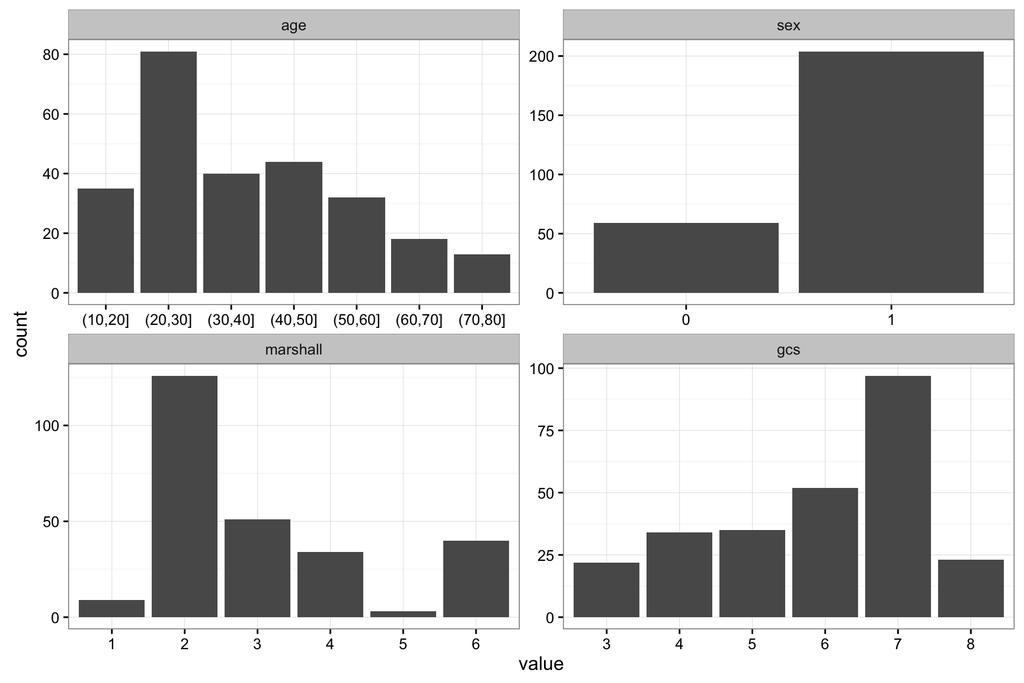

Raw data for the above:

```
## $`Distribution Summary for Variable: age`
##     Value Frequency Percentage
## 1 (10,20]        35      13.31
## 2 (20,30]        81      30.80
## 3 (30,40]        40      15.21
## 4 (40,50]        44      16.73
## 5 (50,60]        32      12.17
## 6 (60,70]        18       6.84
## 7 (70,80]        13       4.94
##
## $`Distribution Summary for Variable: sex`
##   Value Frequency Percentage
## 1     0        59      22.43
## 2     1       204      77.57
##
## $`Distribution Summary for Variable: marshall`
##   Value Frequency Percentage
## 1     1         9       3.42
## 2     2       126      47.91
## 3     3        51      19.39
## 4     4        34      12.93
## 5     5         3       1.14
## 6     6        40      15.21
##
## $`Distribution Summary for Variable: gcs`
##   Value Frequency Percentage
## 1     3        22       8.37
## 2     4        34      12.93
## 3     5        35      13.31
## 4     6        52      19.77
## 5     7        97      36.88
## 6     8        23       8.75
```

### Gas and Pressure Distributions

Distributions of gas and pressure measurements across all applicable samples:

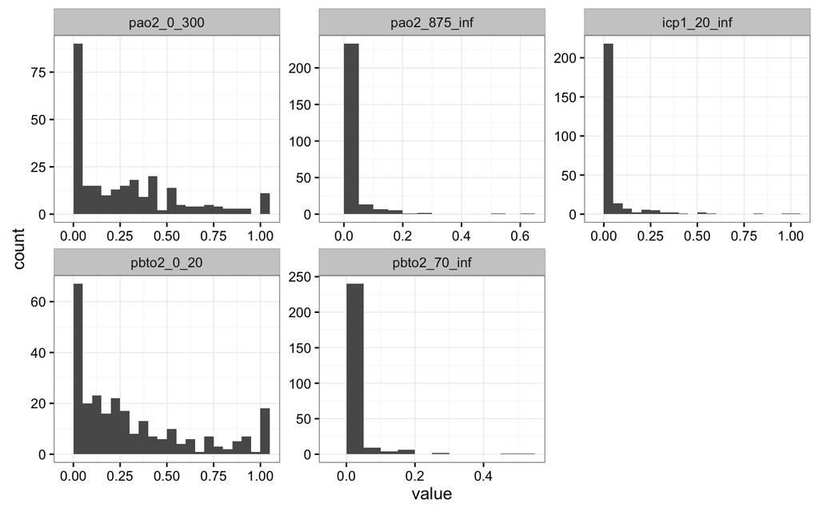

Note that for each variable above, a single patient’s value for that variable was computed as the fraction of time for which the measurements were above or below are particular threshold. Those thresholds are in the names of the variables where a name like `pao2_875_inf` indicates the fraction of time (over all their measurements) the patient had a PaO2 value measured as greater than 875.

# 2. PbtO2 + Outcome

### Results

- **Result 1**: PbtO2 is an important predictor of outcomes
- **Result 2**: PbtO2 is retained in stepwise model selection
- **Result 3**: PbtO2 thresholds are optimal when set at 20 and ~70

#### Result 1: PbtO2 is an important predictor of outcomes

PbtO2 is a significant predictor of outcomes after controlling for age, gender, marshall, and gcs.

Here are results from a linear, logistic model for a “Good vs Bad” outcome (where `outcome = 0 if GOS <= 3, 1 otherwise`) showing this:

| Predictor | Coefficient | Odds.Ratio | P.Value |
| --- | --- | --- | --- |
| (Intercept) | -1.300 | 0.273 | 0 *** |
| age | -0.534 | 0.586 | 0.003 ** |
| sex | 0.148 | 1.160 | 0.356 |
| marshall | -0.280 | 0.756 | 0.142 |
| gcs | 0.443 | 1.557 | 0.01 ** |
| pbto2_0_20 | -0.444 | 0.641 | 0.013 * |
| pbto2_70_inf | -0.255 | 0.775 | 0.238 |

Table: PbtO2 Logistic Model Results (Good vs Bad, n=263)  
Formula = gos ~ age + sex + marshall + gcs + pbto2_0_20 + pbto2_70_inf

#### Result 2: PbtO2 is retained in stepwise model selection

Stepwise model selection (using exhaustive AICc search) for a similar model to the above, but with interactions, again shows that PbtO2 is an important predictor. This shown by the fact that PbtO2 is retained the best model.

Best model chosen after starting with the model in **Result 1** above:

| Predictor | Coefficient | Odds.Ratio | P.Value |
| --- | --- | --- | --- |
| (Intercept) | -1.279 | 0.278 | 0 *** |
| pbto2_0_20 | -0.391 | 0.676 | 0.024 * |
| age | -0.501 | 0.606 | 0.005 ** |
| marshall | -0.296 | 0.744 | 0.118 |
| gcs | 0.466 | 1.594 | 0.007 ** |

Table: PbtO2 Model Selection via AICc (Good vs Bad, n=263)  
Starting Model = gos ~ pbto2_0_20 * (age + sex + marshall + gcs) + pbto2_70_inf * (age + sex + marshall + gcs)  
Best Model = gos ~ 1 + pbto2_0_20 + age + marshall + gcs

Note that the variables `sex` and `pbto2_70_inf` were excluded from the best model.

#### Result 3: PbtO2 thresholds are optimal when set at 20 and ~70

In the models above the lowest and highest values considered to be “safe” for PbtO2 were 20 and 70 respectively. The lower setting for these thresholds, 20, was set based on prior knowledge. The upper setting, however, was determined using a model designed to find these optimal thresholds. This approach was designed to determine which of the following are true:

1. There is **no** threshold in PbtO2 values that best predicts outcomes
2. There is **one** threshold in PbtO2 values for which time spent above and below that value best predict outcomes
3. There are **two** thresholds in PbtO2 values that best predict outcomes

The results from applying this technique shows two things:

1. Time spent (by patients) with PbtO2 values below 15-20 are highly correlated with poor outcomes
2. Time spent with PbtO2 values **above** 70-100 are also correlated with poor outcomes (but less so)

Item #1 above seems to be common knowledge while item #2 is not. To better illustrate why #2 is true, here is a plot of the PbtO2 values for every single patient that ever had a value above 100 and their corresponding GOS outcome:

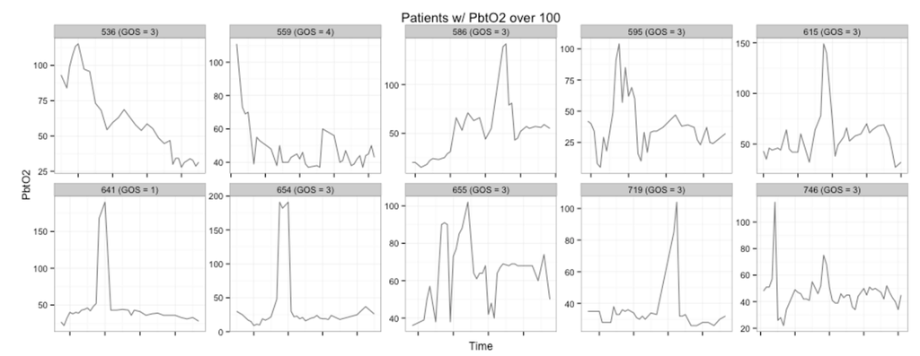

Note that all but one patient had a GOS score of 3 or lower (which are all poor outcomes).

## 3. PbtO2 + Mortality

#### Results

PbtO2 is **not** a signficant predictor of mortality.

Here are the linear modeling coefficient results applied in exactly the same way as with good/bad outcomes, but with a new “Alive vs Dead” outcome defined as `outcome = 0 if GOS = 1, 1 otherwise`:

Model coefficients:

| Predictor | Coefficient | Odds.Ratio | P.Value |
| --- | --- | --- | --- |
| (Intercept) | 1.496 | 4.464 | 0 *** |
| age | -1.247 | 0.287 | 0 *** |
| sex | 0.162 | 1.176 | 0.341 |
| marshall | -0.203 | 0.816 | 0.223 |
| gcs | 0.745 | 2.106 | 0 *** |
| pbto2_0_20 | -0.147 | 0.863 | 0.38 |
| pbto2_70_inf | 0.128 | 1.137 | 0.508 |

Table: PbtO2 Logistic Model Results (Alive vs Dead, n=263)  
Formula = gos ~ age + sex + marshall + gcs + pbto2_0_20 + pbto2_70_inf

Only age and GCS are significant in this case.

Similarly, PbtO2 is also lost in stepwise model selection where the below shows the best model chosen from all combinations of predictors in the model above:

| Predictor | Coefficient | Odds.Ratio | P.Value |
| --- | --- | --- | --- |
| (Intercept) | 1.486 | 4.419 | 0 *** |
| age | -1.326 | 0.266 | 0 *** |
| gcs | 0.786 | 2.195 | 0 *** |

Table: PbtO2 Model Selection via AICc (Alive vs Dead, n=263)  
Starting Model = gos ~ pbto2_0_20 * (age + sex + marshall + gcs) + pbto2_70_inf * (age + sex + marshall + gcs)  
Best Model = gos ~ 1 + age + gcs

Again, only age and GCS are significant while PbtO2, sex, and marshall scores are all lost.

# 4. Findings for PbtO2 vs PaO2 and ICP

### Results

- **Result 1**: PbtO2 vs PaO2 (all samples)
- **Result 2**: PbtO2 vs PaO2 (samples w/ ICP)
- **Result 3**: PbtO2 vs PaO2 vs ICP

#### Result 1: PbtO2 vs PaO2 (all samples)

**Linear Model** - Modeling results when also including PaO2 as predictor across all available samples:

| Predictor | Coefficient | Odds.Ratio | P.Value |
| --- | --- | --- | --- |
| (Intercept) | -1.286 | 0.276 | 0 *** |
| age | -0.501 | 0.606 | 0.006 ** |
| sex | 0.170 | 1.185 | 0.291 |
| marshall | -0.324 | 0.723 | 0.09 . |
| gcs | 0.431 | 1.539 | 0.013 * |
| pbto2_0_20 | -0.388 | 0.678 | 0.028 * |
| pao2_0_300 | -0.137 | 0.872 | 0.401 |

Table: PbtO2 vs PaO2 Logistic Model Results (Good vs Bad, n=262)  
Formula = gos ~ age + sex + marshall + gcs + pbto2_0_20 + pao2_0_300

**Stepwise AICc Model Selection** - Best model chosen via AICc when including PbtO2 and PaO2:

| Predictor | Coefficient | Odds.Ratio | P.Value |
| --- | --- | --- | --- |
| (Intercept) | -1.277 | 0.279 | 0 *** |
| age | -0.510 | 0.600 | 0.004 ** |
| marshall | -0.300 | 0.741 | 0.113 |
| gcs | 0.458 | 1.581 | 0.008 ** |
| pbto2_0_20 | -0.400 | 0.670 | 0.021 * |

Table: PbtO2 vs PaO2 Model Selection via AICc (Good vs Bad, n=262)  
Starting Model = gos ~ age + sex + marshall + gcs + pbto2_0_20 * pao2_0_300  
Best Model = gos ~ 1 + age + marshall + gcs + pbto2_0_20

**LOOCV Model Selection** - Model selection results from leave-one-out cross validation looking at ROC AUC:

| Model | AUC |
| --- | --- |
| * gos ~ age + marshall + gcs + pbto2_0_20 | 0.6873 |
| gos ~ age + sex + marshall + gcs + pbto2_0_20 + pao2_0_300 | 0.686 |
| gos ~ age + sex + marshall + gcs + pbto2_0_20 | 0.6855 |
| gos ~ age + marshall + gcs + pbto2_0_20 + pao2_0_300 | 0.6847 |
| gos ~ age + marshall + gcs + pao2_0_300 | 0.684 |

Table: Top 5 PbtO2 vs PaO2 Models by AUC (Good vs Bad, n=262)  
* Best Model (higher AUC is better)

#### Result 2: PbtO2 vs PaO2 (samples w/ ICP)

**Linear Model** - Results for the same model as the previous section (PaO2 vs PbtO2), but where the data for the model is restricted to only samples available for all of PbtO2, PaO2, and ICP:

| Predictor | Coefficient | Odds.Ratio | P.Value |
| --- | --- | --- | --- |
| (Intercept) | -1.256 | 0.285 | 0 *** |
| age | -0.448 | 0.639 | 0.043 * |
| sex | 0.163 | 1.177 | 0.414 |
| marshall | -0.387 | 0.679 | 0.104 |
| gcs | 0.305 | 1.357 | 0.165 |
| pbto2_0_20 | -0.498 | 0.608 | 0.025 * |
| pao2_0_300 | 0.059 | 1.061 | 0.767 |

Table: PbtO2 vs PaO2 Logistic Model Results on Smaller Sample (Good vs Bad, n=166)  
Formula = gos ~ age + sex + marshall + gcs + pbto2_0_20 + pao2_0_300

**Stepwise AICc Model Selection** - Best model chosen via AICc when including PbtO2 and PaO2 (with data limited to only samples avaiable for ICP):

| Predictor | Coefficient | Odds.Ratio | P.Value |
| --- | --- | --- | --- |
| (Intercept) | -1.246 | 0.288 | 0 *** |
| age | -0.424 | 0.654 | 0.052 . |
| marshall | -0.369 | 0.691 | 0.117 |
| gcs | 0.327 | 1.387 | 0.133 |
| pbto2_0_20 | -0.478 | 0.620 | 0.027 * |

Table: PbtO2 vs PaO2 Model Selection via AICc on Smaller Sample (Good vs Bad, n=166)  
Starting Model = gos ~ age + sex + marshall + gcs + pbto2_0_20 * pao2_0_300  
Best Model = gos ~ 1 + age + marshall + gcs + pbto2_0_20

**LOOCV Model Selection** - Model selection results from leave-one-out cross validation looking at ROC AUC:

| Model | AUC |
| --- | --- |
| * gos ~ age + marshall + gcs + pbto2_0_20 | 0.6655 |
| gos ~ age + marshall + pbto2_0_20 | 0.6582 |
| gos ~ age + sex + marshall + gcs + pbto2_0_20 | 0.6563 |
| gos ~ marshall + gcs + pbto2_0_20 | 0.6525 |
| gos ~ age + marshall + gcs + pbto2_0_20 + pao2_0_300 | 0.6523 |

Table: Top 5 PbtO2 vs PaO2 Models by AUC on Smaller Sample (Good vs Bad, n=166)  
* Best Model (higher AUC is better)

#### Result 3: PbtO2 vs PaO2 vs ICP

**Linear Model** - Results for a logistic model including PbtO2, PaO2, and ICP:

| Predictor | Coefficient | Odds.Ratio | P.Value |
| --- | --- | --- | --- |
| (Intercept) | -1.393 | 0.248 | 0 *** |
| age | -0.600 | 0.549 | 0.011 * |
| sex | 0.212 | 1.236 | 0.304 |
| marshall | -0.330 | 0.719 | 0.168 |
| gcs | 0.338 | 1.402 | 0.134 |
| pbto2_0_20 | -0.426 | 0.653 | 0.06 . |
| pao2_0_300 | 0.029 | 1.029 | 0.889 |
| icp1_20_inf | -0.861 | 0.423 | 0.038 * |

Table: PbtO2 vs PaO2 vs ICP Logistic Model Results (Good vs Bad, n=166)  
Formula = gos ~ age + sex + marshall + gcs + pbto2_0_20 + pao2_0_300 + icp1_20_inf

**Stepwise AICc Model Selection** - Best model chosen via AICc when including PbtO2, PaO2, and ICP:

| Predictor | Coefficient | Odds.Ratio | P.Value |
| --- | --- | --- | --- |
| (Intercept) | -1.356 | 0.258 | 0 *** |
| age | -0.666 | 0.514 | 0.002 ** |
| gcs | 0.432 | 1.540 | 0.046 * |
| pbto2_0_20 | -0.404 | 0.668 | 0.069 . |
| icp1_20_inf | -0.880 | 0.415 | 0.033 * |

Table: PbtO2 vs PaO2 vs ICP Model Selection via AICc (Good vs Bad, n=166)  
Starting Model = gos ~ age + sex + marshall + gcs + pbto2_0_20 + pao2_0_300 + icp1_20_inf  
Best Model = gos ~ 1 + age + gcs + pbto2_0_20 + icp1_20_inf

**LOOCV Model Selection** - Model selection results from leave-one-out cross validation looking at ROC AUC:

| Model | AUC |
| --- | --- |
| * gos ~ age + sex + marshall + gcs + pbto2_0_20 + icp1_20_inf | 0.6837 |
| gos ~ age + marshall + gcs + pbto2_0_20 + icp1_20_inf | 0.6812 |
| gos ~ age + sex + marshall + pbto2_0_20 + icp1_20_inf | 0.681 |
| gos ~ age + marshall + pbto2_0_20 + icp1_20_inf | 0.6799 |
| gos ~ age + gcs + pbto2_0_20 + icp1_20_inf | 0.6795 |

Table: Top 5 PbtO2 vs PaO2 vs ICP Models by AUC (Good vs Bad, n=166)  
* Best Model (higher AUC is better)

# 5. Conclusions

Summary of findings:

- Thresholding models show that a lower boundary for PbtO2 of 15-20 is ideal
- The same threshold models also suggest that an upper bound on PbtO2 of 70+ may be correlated with bad outcomes
- PbtO2 is a stronger predictor of outcomes than PaO2. This was confirmed by stepwise model selection, cross-validation, and predictor statistical significance.
- ICP is also a significant predictor of outcomes. For model spaces that include all of ICP, PbtO2, and PaO2, model selection via AICc and cross validation both show that PaO2 is not as important as PbtO2 and ICP (though both of these are important).